# Logistic Regression Tutorial

Nick Broussard

9/11/2019

A topic I find super interesting is municipal action against AirBNB, VRBO, and other (so designated) short term rental companies. In Austin, residents are supposed to registered with the City before gigging out their rooms/homes. There’s virtually no incentive to register with the City, however, because the City doesn’t enforce compliance. As with most government regulations, compliance is regulated through resident complaints. They have no other way of knowing if I’m doing AirBNB unless my neighbor submits some kind of complaint. City’s generally (1) are understaffed, and (2) don’t know how to use technology (like getting on airbnb.com and searching for homes, then comparing listings against registrations). Even without any real enforcement arm, lot’s of people get turned in. To explore complaint-based enforcement, I want to use the City of Austin’s [“Short Term Rental Legal Outcomes”](https://data.austintexas.gov/City-Government/Short-Term-Rental-Legal-Outcomes/xfmy-m22z) data set. Between 2018 and 2019, there are 3,472 cases listed, in which many are cited for not registering their homes before gigging.

I’m asking if the likeliood of a conviction, given a legal charge, is affected by the type of charge, the fee associated with the charge, and the months the violation is open before the final judicial decision.

## Explore and Clean

First, read in the df.

Second, select variables.

Third, look at the df’s structure…

Observations: 3,472 Variables: 5 $ VIOLATIONOPENDATE “01/23/2018 12:00:00 AM +0000”, “01/23/2018 12:00… $ DEFICIENCYTEXT ”A person must obtain a license to operate a shor… $ OUTSTANDINGFEE 0, 0, 0, 1000, 628, 0, 1128, 1000, 0, 0, 0, 1128,… $ LEGALOUTCOME “Liable”, “Liable”, “Liable”, “Liable”, “Liable”,… $ LEGALOUTCOMEDATE “02/21/2019 12:00:00 AM +0000”, "02/21/2019 12:00… …and convert variables accordingly.

Fourth, inspect the categoricals.

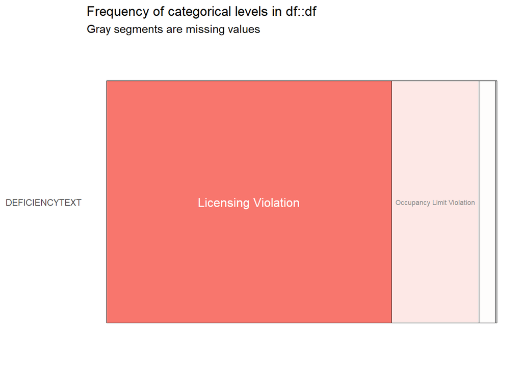

Based on distributions, restrict if appropriate.

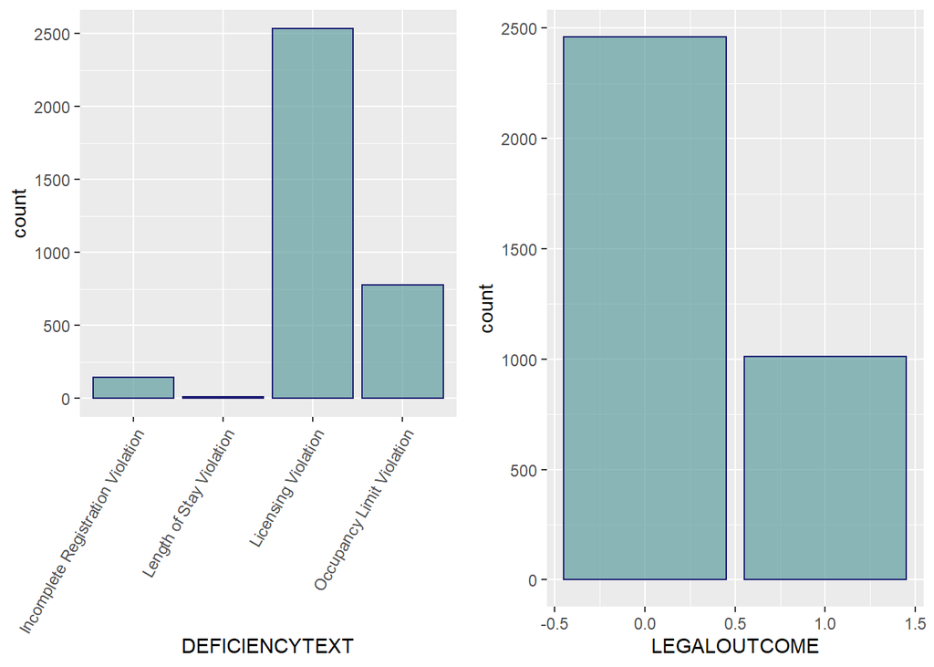

Fifth, inspect numerics by calling the 5-number-summary…

|  | Min | Q1 | Median | Q3 | Max |
| --- | --- | --- | --- | --- | --- |
| **LEGALOUTCOME** | 0.00 | 0.00 | 0.00 | 1.00 | 1.00 |
| **MONTHSVIOLATIONOPEN** | 0.00 | 3.00 | 5.00 | 12.00 | 17.00 |
| **OUTSTANDINGFEE** | -250.00 | 0.00 | 0.00 | 830.00 | 1128.00 |

…and histogram distributions…

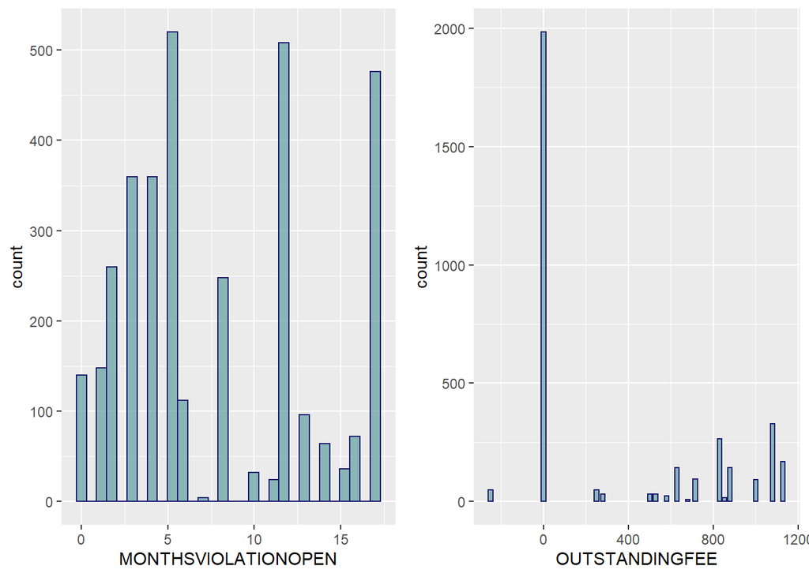

…and for outliers.

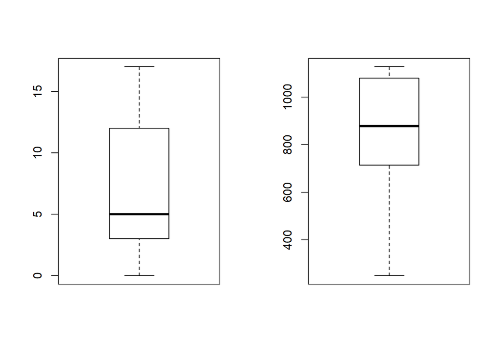

Sixth, check missingness…

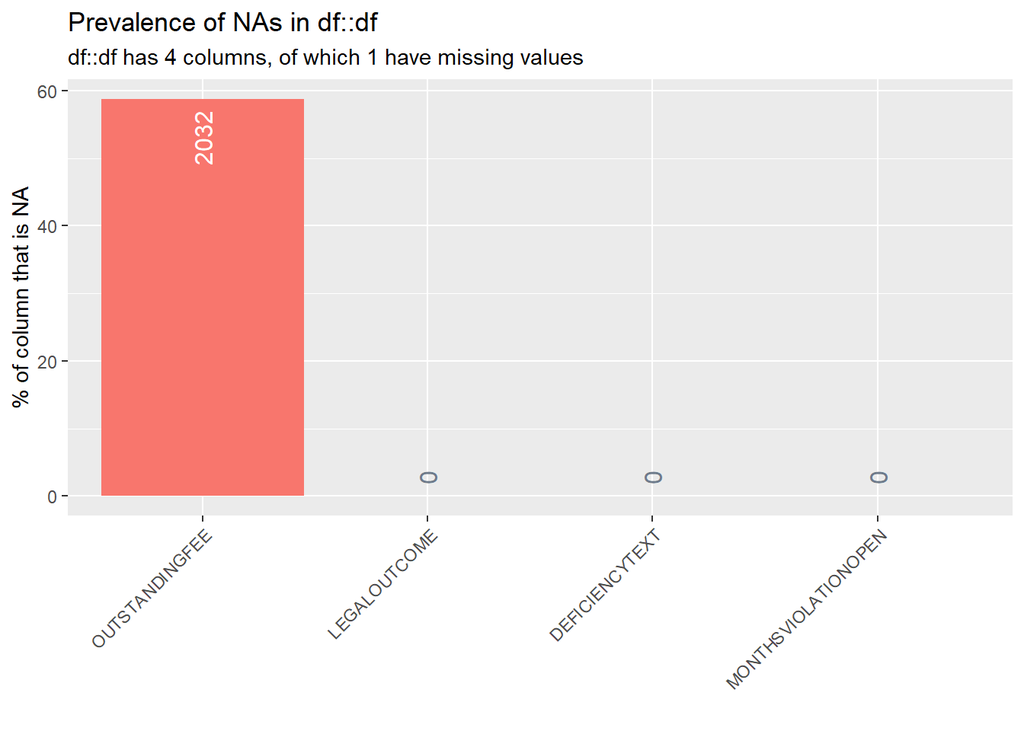

and impute…

Seventh, and last, check correlation.

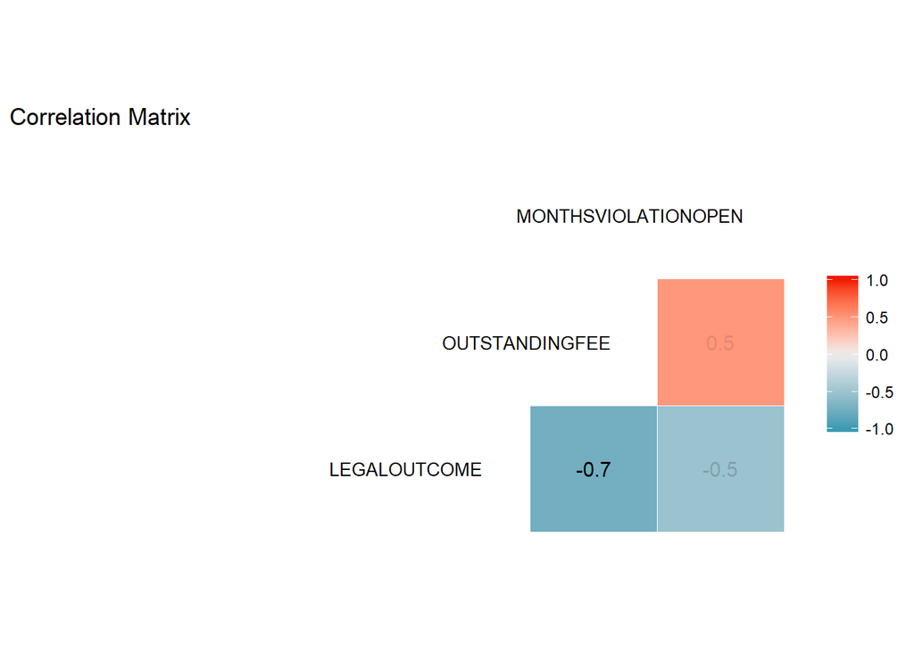

The threshold for multicolinearity of .7 is achieved only between reponse and predictor variables. No issue.

## Model

Split.

Build and interpret the model.

| Observations | 1730 |
| --- | --- |
| Dependent variable | LEGALOUTCOME |
| Type | Generalized linear model |
| Family | binomial |
| Link | logit |

| χ²(4) | 1401.3503 |
| --- | --- |
| Pseudo-R² (Cragg-Uhler) | 0.7968 |
| Pseudo-R² (McFadden) | 0.6790 |
| AIC | 672.6105 |
| BIC | 699.8899 |

|  | exp(Est.) | 2.5% | 97.5% | z val. | p | VIF |
| --- | --- | --- | --- | --- | --- | --- |
| (Intercept) | 906.6708 | 304.5271 | 2699.4378 | 12.2334 | 0.0000 | NA |
| DEFICIENCYTEXTLicensing Violation | 1.6686 | 0.7361 | 3.7826 | 1.2262 | 0.2201 | 1.5429 |
| DEFICIENCYTEXTOccupancy Limit Violation | 10.9809 | 3.5870 | 33.6155 | 4.1976 | 0.0000 | 1.5429 |
| OUTSTANDINGFEE | 0.9890 | 0.9876 | 0.9903 | -16.2259 | 0.0000 | 1.2070 |
| MONTHSVIOLATIONOPEN | 0.8138 | 0.7669 | 0.8637 | -6.7929 | 0.0000 | 1.3585 |

Standard errors: MLE

Model: $\ y=907+1.67*LicensingViolation+10.98*OccupancyViolation+0.98*OutstandingFee+0.81*MonthsOpen$

For the outcome variable, 0 is not penalized and 1 is penalized. Reference category for DEFICIENCYTEXT is RegistrationViolation.

Interpretation: * A licensing violation is 66% more likely to result in a penalty than an incomplete registration violation controlling for all other variables. Not staistically significant. * An occupancy limit violation is 11x (1,098%) more likely to result in a penalty than an incomplete registration violation. * For every $1 increase in outstanding fee the likelihood of penalty decreases by 1% (1-.989). * For every month that the violation is open the likelhood of penalty decreases by 19% (1-.81).

Third, conduct graphical analysis. Analyze coefficients…

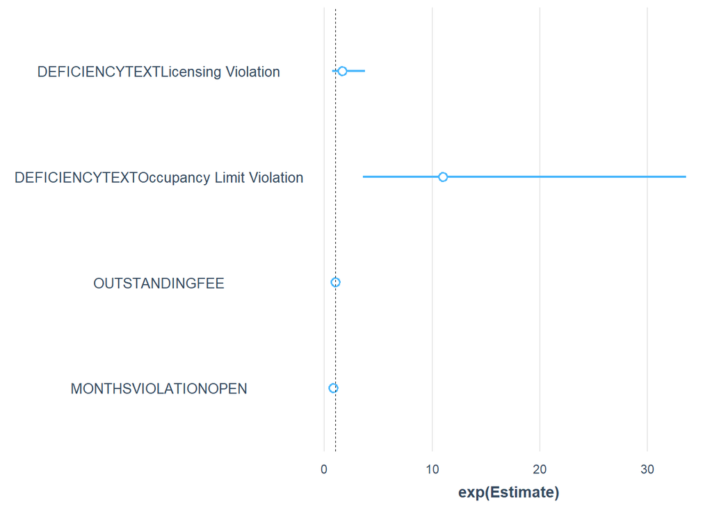

..and look at the relationship between predictors and the outcome.

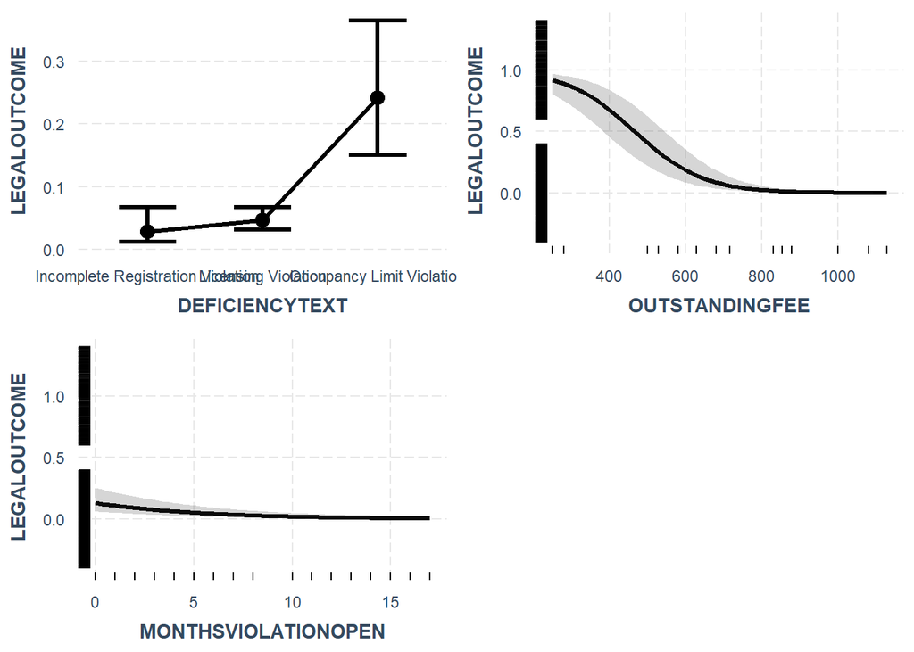

Fourth, pull in fitted and residual values…

…and query the model.

Fifth, evaluate goodness of fit. Start with running an ANOVA…

Analysis of Deviance Table

Model: binomial, link: logit

Response: LEGALOUTCOME

Terms added sequentially (first to last)

[output not shown]

Null Deviance: 2063.9608186 Residual Deviance: 2063.9608186, 1995.7758938, 720.2714454, 662.6105188 AIC: 672.6105188

…then run an ROC curve and a confusion matrix.

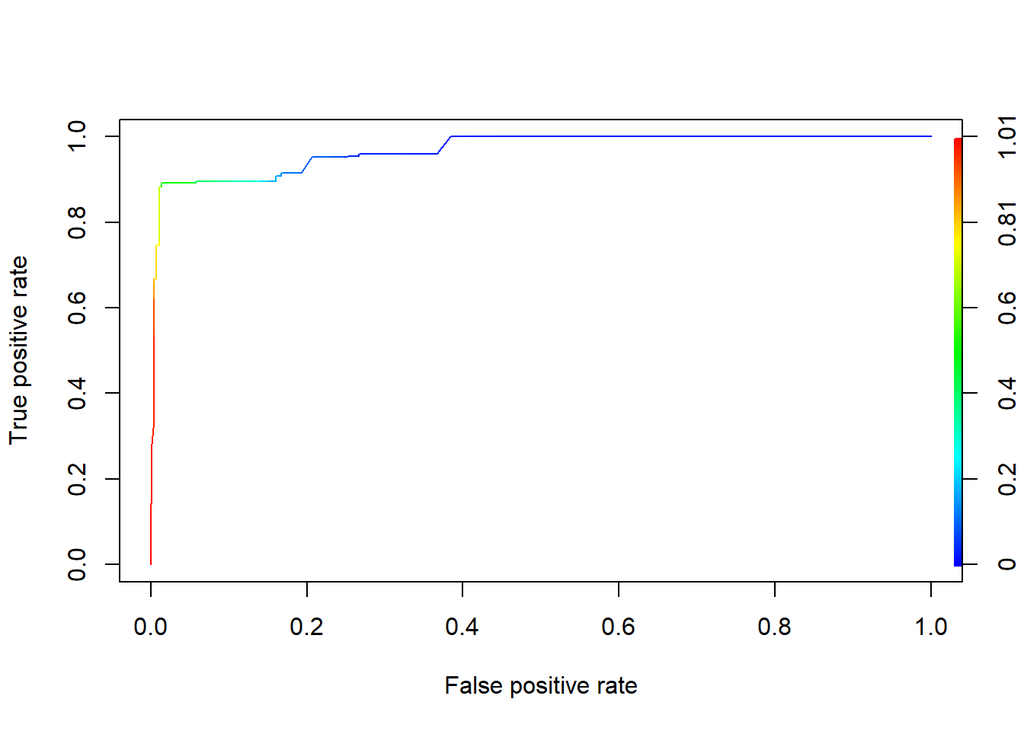

FALSE TRUE 0 1222 17 1 53 438

Sixth, and last, run a new set of predicted values from the test set, then run another confusion matrix and compare.

FALSE TRUE 0 1197 24 1 58 451

## Compare

Build another model with fewer predictors.

| Observations | 1730 |
| --- | --- |
| Dependent variable | LEGALOUTCOME |
| Type | Generalized linear model |
| Family | binomial |
| Link | logit |

| χ²(2) | 1374.1323 |
| --- | --- |
| Pseudo-R² (Cragg-Uhler) | 0.7867 |
| Pseudo-R² (McFadden) | 0.6658 |
| AIC | 695.8285 |
| BIC | 712.1962 |

|  | exp(Est.) | 2.5% | 97.5% | z val. | p | VIF |
| --- | --- | --- | --- | --- | --- | --- |
| (Intercept) | 959.6733 | 443.4580 | 2076.7983 | 17.4332 | 0.0000 | NA |
| OUTSTANDINGFEE | 0.9896 | 0.9884 | 0.9908 | -16.4854 | 0.0000 | 1.0389 |
| MONTHSVIOLATIONOPEN | 0.8555 | 0.8110 | 0.9024 | -5.7302 | 0.0000 | 1.0389 |

Standard errors: MLE

Compare as a side-by-side table…

|  | Model 1 | Model 2 |
| --- | --- | --- |
| (Intercept) | -3.54 *** | -2.59 *** |
|  | [-4.45,-2.63] | [-2.92,-2.26] |
| DEFICIENCYTEXTLicensing Violation | 0.51 |  |
|  | [-0.31,1.33] |  |
| DEFICIENCYTEXTOccupancy Limit Violation | 2.40 *** |  |
|  | [1.28,3.51] |  |
| OUTSTANDINGFEE | -3.30 *** | -3.11 *** |
|  | [-3.69,-2.90] | [-3.48,-2.74] |
| MONTHSVIOLATIONOPEN | -1.13 *** | -0.86 *** |
|  | [-1.45,-0.80] | [-1.15,-0.56] |
| N | 1730 | 1730 |
| AIC | 672.61 | 695.83 |
| BIC | 699.89 | 712.20 |
| Pseudo R2 | 0.80 | 0.79 |
| *** p < 0.001; ** p < 0.01; * p < 0.05. |  |  |

… and graphically by coefficients.

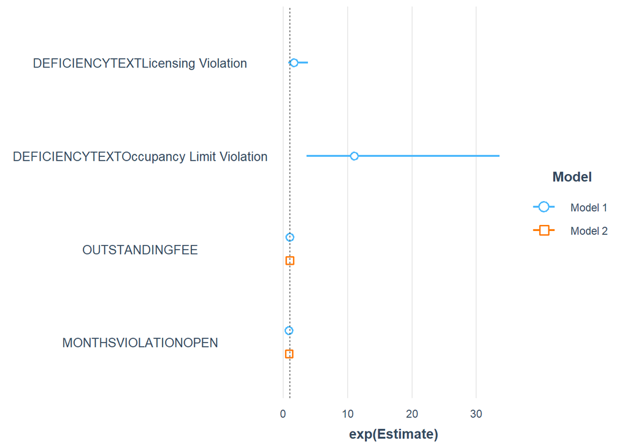

## Sources

- https://datascienceplus.com/perform-logistic-regression-in-r/
- https://www.datacamp.com/community/tutorials/logistic-regression-R
- https://towardsdatascience.com/simply-explained-logistic-regression-with-example-in-r-b919acb1d6b3
- https://www.theanalysisfactor.com/r-glm-model-fit/
- http://r-statistics.co/Logistic-Regression-With-R.html
- https://webfocusinfocenter.informationbuilders.com/wfappent/TLs/TL_rstat/source/LogisticRegression43.htm
- AIC and Model Parsimony: https://www.r-bloggers.com/how-do-i-interpret-the-aic/
- https://www.analyticsvidhya.com/blog/2015/11/beginners-guide-on-logistic-regression-in-r/
- effect_plot in jtools: https://cran.r-project.org/web/packages/jtools/vignettes/effect_plot.html
- Beginner’s Guide to Logistic Regression: https://www.analyticsvidhya.com/blog/2015/11/beginners-guide-on-logistic-regression-in-r/